# Google Data Analytics Capstone project

Cyclistic Case Study

Kshitij Kshirsagar

24/05/2022

This case study is a part of Google’s Data Analytics Professional certificate course which can be found [click](https://www.coursera.org/professional-certificates/google-data-analytics?). This course manages to teach all those skills that a data analysts requires to do their analysis.

## Cyclistics Bike-Share Analysis Case Study

This is the first case study of Google Capstone Project. I will be following the data analysis process which consists of :- Ask,Prepare,Process,Analyze,Share and Act.

## Scenario

The director of marketing of Cyclistic, Lily Moreno, believes that the company’s future growth depends on maximizing the number of annual memberships. Hence, the marketing analyst team wants to understand how casual riders and annual members use Cyclistic bikes differently. From these insights, the analytics team could be able to design a new marketing strategy to convert casual riders into annual members.

Three questions will guide the future marketing campaign:

1.How do annual members and casual riders use Cyclistic bikes differently?

2.Why would casual riders buy Cyclistic annual memberships?

3.How can Cyclistic use digital media to influence casual riders to become members?

## Asking Phase

**Cyclistic** : A bike-share program that features more than 5,800 bicycles and 600 docking stations. Cyclistic sets itself apart by also offering reclining bikes, hand tricycles, and cargo bikes, making bike-share more inclusive to people with disabilities and riders who can’t use a standard two-wheeled bike. The majority of riders opt for traditional bikes; about 8% of riders use the assertive options. Cyclistic users are more likely to ride for leisure, but about 30% use them to commute to work each day.

Cyclistic has concluded that annual members are much more profitable than casual riders. So, we want to design a marketing strategies and a campaign that helps us converting casual riders into annual members.

**Key Stakeholders**

- Lily Monreno : The director of marketing and your manager. Moreno is responsible for the development of campaigns and initiatives to promote the bike-share program. These may include email, social media, and other channels.
- Cyclistic marketing analytics team : A team of data analysts who are responsible for collecting, analyzing, and reporting data that helps guide Cyclistic marketing strategy. You joined this team six months ago and have been busy learning about Cyclistic’s mission and business goals — as well as how you, as a junior data analyst, can help Cyclistic achieve them.
- Cyclistic executive team : The notoriously detail-oriented executive team will decide whether to approve the recommended marketing program.

#### Guiding Questions

- **Where is your data located?**

  Build a profile for annual member and convert casual riders into annual riders.
- **How can your insights drive business decisions?**

  My Insights will help the marketing team increase annual members.

## Prepare Phase

Data Source: Past 12 months of original bike share data set from 01/01/2021 to 31/12/2021 was Collected from [files](https://divvy-tripdata.s3.amazonaws.com/index.html). The data is made available and licensed by Motivate International Inc under this [license](https://ride.divvybikes.com/data-license-agreement).

#### Guiding Questions

- **Where is your data located?**

  Data is located here https://divvy-tripdata.s3.amazonaws.com/index.html.
- **How is the data oragnized?**

  The data set is separated by months with identical label columns.
- **Are there issues with bias or credibility in this data? Does your data ROCCC?**

  I do not think there are any bias because the dataset belongs to their client.The data is credible and it is reliable, original, comprehensive, current and cited by Chicago Department of Transportation.
- **How are you addressing licensing, privacy, security, and accessibility?**

  The data do not have any personal information and the company handles the licensing.
- **How did you verify the data’s integrity?**

  All dataset have identical columns and have the correct type of data.
- **How does it help you answer your question?**

  It has relevant data to answer my questions.

## Process Phase

I used R for data verification and cleaning.The 12 data sets contain more than 5 million rows of data. Excel worksheets or spreadsheets have limitations of 1,048,576 rows. Moreover, some csv files could not be loaded on BigQuery due to big file sizes. Therefore R is used to perform all tasks from organizing, cleaning and visualizing data.

#### Setting up the environment

Here, I will be using several libraries that will be help in reading, cleaning, organizing and analyzing the data.

```r
library(tidyverse)
library(janitor)
library(skimr)
library(here)
library(hablar)
library(readxl)
library(data.table)
library(chron)
library(readr)
library(lubridate)
library(magrittr)
library(DescTools)
library(metR)
```

## Setting up the present working directory

```r
setwd("C:/Users/FlasH/Desktop") #for setting the current working directory
```

## Importing data

Cyclist data from 01-2021 until 12-2021 is imported and read as .csv files.

```r
data_01 <- read_csv("202101-divvy-tripdata/202101-divvy-tripdata.csv")
data_02 <- read_csv("202101-divvy-tripdata/202102-divvy-tripdata.csv")
data_03 <- read_csv("202101-divvy-tripdata/202103-divvy-tripdata.csv")
data_04 <- read_csv("202101-divvy-tripdata/202104-divvy-tripdata.csv")
data_05 <- read_csv("202101-divvy-tripdata/202105-divvy-tripdata.csv")
data_06 <- read_csv("202101-divvy-tripdata/202106-divvy-tripdata.csv")
data_07 <- read_csv("202101-divvy-tripdata/202107-divvy-tripdata.csv")
data_08 <- read_csv("202101-divvy-tripdata/202108-divvy-tripdata.csv")
data_09 <- read_csv("202101-divvy-tripdata/202109-divvy-tripdata.csv")
data_10 <- read_csv("202101-divvy-tripdata/202110-divvy-tripdata.csv")
data_11 <- read_csv("202101-divvy-tripdata/202111-divvy-tripdata.csv")
data_12 <- read_csv("202101-divvy-tripdata/202112-divvy-tripdata.csv")
```

Compare column names of each files. While the names don’t have to be in the same order, they do need to be matched perfectly before they are joined together into a single file.

```r
# get column names of all data frames
colnames(data_01)
```

```
##  [1] "ride_id"            "rideable_type"      "started_at"
##  [4] "ended_at"           "start_station_name" "start_station_id"
##  [7] "end_station_name"   "end_station_id"     "start_lat"
## [10] "start_lng"          "end_lat"            "end_lng"
## [13] "member_casual"
```

```r
colnames(data_02)
```

```
##  [1] "ride_id"            "rideable_type"      "started_at"
##  [4] "ended_at"           "start_station_name" "start_station_id"
##  [7] "end_station_name"   "end_station_id"     "start_lat"
## [10] "start_lng"          "end_lat"            "end_lng"
## [13] "member_casual"
```

```r
colnames(data_04)
```

```
##  [1] "ride_id"            "rideable_type"      "started_at"
##  [4] "ended_at"           "start_station_name" "start_station_id"
##  [7] "end_station_name"   "end_station_id"     "start_lat"
## [10] "start_lng"          "end_lat"            "end_lng"
## [13] "member_casual"
```

```r
colnames(data_05)
```

```
##  [1] "ride_id"            "rideable_type"      "started_at"
##  [4] "ended_at"           "start_station_name" "start_station_id"
##  [7] "end_station_name"   "end_station_id"     "start_lat"
## [10] "start_lng"          "end_lat"            "end_lng"
## [13] "member_casual"
```

```r
colnames(data_06)
```

```
##  [1] "ride_id"            "rideable_type"      "started_at"
##  [4] "ended_at"           "start_station_name" "start_station_id"
##  [7] "end_station_name"   "end_station_id"     "start_lat"
## [10] "start_lng"          "end_lat"            "end_lng"
## [13] "member_casual"
```

```r
colnames(data_07)
```

```
##  [1] "ride_id"            "rideable_type"      "started_at"
##  [4] "ended_at"           "start_station_name" "start_station_id"
##  [7] "end_station_name"   "end_station_id"     "start_lat"
## [10] "start_lng"          "end_lat"            "end_lng"
## [13] "member_casual"
```

```r
colnames(data_08)
```

```
##  [1] "ride_id"            "rideable_type"      "started_at"
##  [4] "ended_at"           "start_station_name" "start_station_id"
##  [7] "end_station_name"   "end_station_id"     "start_lat"
## [10] "start_lng"          "end_lat"            "end_lng"
## [13] "member_casual"
```

```r
colnames(data_09)
```

```
##  [1] "ride_id"            "rideable_type"      "started_at"
##  [4] "ended_at"           "start_station_name" "start_station_id"
##  [7] "end_station_name"   "end_station_id"     "start_lat"
## [10] "start_lng"          "end_lat"            "end_lng"
## [13] "member_casual"
```

```r
colnames(data_10)
```

```
##  [1] "ride_id"            "rideable_type"      "started_at"
##  [4] "ended_at"           "start_station_name" "start_station_id"
##  [7] "end_station_name"   "end_station_id"     "start_lat"
## [10] "start_lng"          "end_lat"            "end_lng"
## [13] "member_casual"
```

```r
colnames(data_11)
```

```
##  [1] "ride_id"            "rideable_type"      "started_at"
##  [4] "ended_at"           "start_station_name" "start_station_id"
##  [7] "end_station_name"   "end_station_id"     "start_lat"
## [10] "start_lng"          "end_lat"            "end_lng"
## [13] "member_casual"
```

```r
colnames(data_12)
```

```
##  [1] "ride_id"            "rideable_type"      "started_at"
##  [4] "ended_at"           "start_station_name" "start_station_id"
##  [7] "end_station_name"   "end_station_id"     "start_lat"
## [10] "start_lng"          "end_lat"            "end_lng"
## [13] "member_casual"
```

Stacking the datasets

```r
#combine all data frames
all_trips <- bind_rows(data_01, data_02, data_03, data_04, data_05, data_06, data_07, data_08, data_09, data_10, data_11, data_12)
```

#### Clean up and organize data to prepare for analysis

Inspect the new table that has been created.

```r
colnames(all_trips)  #List of column names
```

```
##  [1] "ride_id"            "rideable_type"      "started_at"
##  [4] "ended_at"           "start_station_name" "start_station_id"
##  [7] "end_station_name"   "end_station_id"     "start_lat"
## [10] "start_lng"          "end_lat"            "end_lng"
## [13] "member_casual"
```

```r
dim(all_trips)  #Dimensions of the data frame
```

```
## [1] 5595063      13
```

```r
head(all_trips)  #See the first 6 rows of data frame
```

```
## # A tibble: 6 × 13
##   ride_id rideable_type started_at          ended_at            start_station_n…
##   <chr>   <chr>         <dttm>              <dttm>              <chr>
## 1 E19E6F… electric_bike 2021-01-23 16:14:19 2021-01-23 16:24:44 California Ave …
## 2 DC88F2… electric_bike 2021-01-27 18:43:08 2021-01-27 18:47:12 California Ave …
## 3 EC45C9… electric_bike 2021-01-21 22:35:54 2021-01-21 22:37:14 California Ave …
## 4 4FA453… electric_bike 2021-01-07 13:31:13 2021-01-07 13:42:55 California Ave …
## 5 BE5E8E… electric_bike 2021-01-23 02:24:02 2021-01-23 02:24:45 California Ave …
## 6 5D8969… electric_bike 2021-01-09 14:24:07 2021-01-09 15:17:54 California Ave …
## # … with 8 more variables: start_station_id <chr>, end_station_name <chr>,
## #   end_station_id <chr>, start_lat <dbl>, start_lng <dbl>, end_lat <dbl>,
## #   end_lng <dbl>, member_casual <chr>
```

```r
str(all_trips)  #See list of columns and data types (numeric, character, etc)
```

```
## spec_tbl_df [5,595,063 × 13] (S3: spec_tbl_df/tbl_df/tbl/data.frame)
##  $ ride_id           : chr [1:5595063] "E19E6F1B8D4C42ED" "DC88F20C2C55F27F" "EC45C94683FE3F27" "4FA453A75AE377DB" ...
##  $ rideable_type     : chr [1:5595063] "electric_bike" "electric_bike" "electric_bike" "electric_bike" ...
##  $ started_at        : POSIXct[1:5595063], format: "2021-01-23 16:14:19" "2021-01-27 18:43:08" ...
##  $ ended_at          : POSIXct[1:5595063], format: "2021-01-23 16:24:44" "2021-01-27 18:47:12" ...
##  $ start_station_name: chr [1:5595063] "California Ave & Cortez St" "California Ave & Cortez St" "California Ave & Cortez St" "California Ave & Cortez St" ...
##  $ start_station_id  : chr [1:5595063] "17660" "17660" "17660" "17660" ...
##  $ end_station_name  : chr [1:5595063] NA NA NA NA ...
##  $ end_station_id    : chr [1:5595063] NA NA NA NA ...
##  $ start_lat         : num [1:5595063] 41.9 41.9 41.9 41.9 41.9 ...
##  $ start_lng         : num [1:5595063] -87.7 -87.7 -87.7 -87.7 -87.7 ...
##  $ end_lat           : num [1:5595063] 41.9 41.9 41.9 41.9 41.9 ...
##  $ end_lng           : num [1:5595063] -87.7 -87.7 -87.7 -87.7 -87.7 ...
##  $ member_casual     : chr [1:5595063] "member" "member" "member" "member" ...
##  - attr(*, "spec")=
##   .. cols(
##   ..   ride_id = col_character(),
##   ..   rideable_type = col_character(),
##   ..   started_at = col_datetime(format = ""),
##   ..   ended_at = col_datetime(format = ""),
##   ..   start_station_name = col_character(),
##   ..   start_station_id = col_character(),
##   ..   end_station_name = col_character(),
##   ..   end_station_id = col_character(),
##   ..   start_lat = col_double(),
##   ..   start_lng = col_double(),
##   ..   end_lat = col_double(),
##   ..   end_lng = col_double(),
##   ..   member_casual = col_character()
##   .. )
##  - attr(*, "problems")=<externalptr>
```

```r
nrow(all_trips) #Number of rows
```

```
## [1] 5595063
```

Columns that list the date, month, day, day_of_week and year of each ride are added. Days of the week are assigned the numbers 1:Monday, 2:Tuesday, etc. This will allow the aggregation of the data by each day, month or day_of_week.

```r
all_trips$date <- as.Date(all_trips$started_at) #The default format is yyyy-mm-dd
all_trips$month <- format(as.Date(all_trips$date), "%m")
all_trips$day <- format(as.Date(all_trips$date), "%d")
all_trips$year <- format(as.Date(all_trips$date), "%Y")
all_trips$day_of_week <- format(as.Date(all_trips$date), "%u") #"%A" would deliver names of weekdays
```

Add a “ride_length” calculation to all_trips in seconds and in minutes.

```r
all_trips$ride_length <- difftime(all_trips$ended_at,all_trips$started_at)
all_trips$ride_length_m <- (difftime(all_trips$ended_at,all_trips$started_at))/60
```

Inspect the structure of the newly added columns.

```r
str(all_trips)
```

```
## spec_tbl_df [5,595,063 × 20] (S3: spec_tbl_df/tbl_df/tbl/data.frame)
##  $ ride_id           : chr [1:5595063] "E19E6F1B8D4C42ED" "DC88F20C2C55F27F" "EC45C94683FE3F27" "4FA453A75AE377DB" ...
##  $ rideable_type     : chr [1:5595063] "electric_bike" "electric_bike" "electric_bike" "electric_bike" ...
##  $ started_at        : POSIXct[1:5595063], format: "2021-01-23 16:14:19" "2021-01-27 18:43:08" ...
##  $ ended_at          : POSIXct[1:5595063], format: "2021-01-23 16:24:44" "2021-01-27 18:47:12" ...
##  $ start_station_name: chr [1:5595063] "California Ave & Cortez St" "California Ave & Cortez St" "California Ave & Cortez St" "California Ave & Cortez St" ...
##  $ start_station_id  : chr [1:5595063] "17660" "17660" "17660" "17660" ...
##  $ end_station_name  : chr [1:5595063] NA NA NA NA ...
##  $ end_station_id    : chr [1:5595063] NA NA NA NA ...
##  $ start_lat         : num [1:5595063] 41.9 41.9 41.9 41.9 41.9 ...
##  $ start_lng         : num [1:5595063] -87.7 -87.7 -87.7 -87.7 -87.7 ...
##  $ end_lat           : num [1:5595063] 41.9 41.9 41.9 41.9 41.9 ...
##  $ end_lng           : num [1:5595063] -87.7 -87.7 -87.7 -87.7 -87.7 ...
##  $ member_casual     : chr [1:5595063] "member" "member" "member" "member" ...
##  $ date              : Date[1:5595063], format: "2021-01-23" "2021-01-27" ...
##  $ month             : chr [1:5595063] "01" "01" "01" "01" ...
##  $ day               : chr [1:5595063] "23" "27" "21" "07" ...
##  $ year              : chr [1:5595063] "2021" "2021" "2021" "2021" ...
##  $ day_of_week       : chr [1:5595063] "6" "3" "4" "4" ...
##  $ ride_length       : 'difftime' num [1:5595063] 625 244 80 702 ...
##   ..- attr(*, "units")= chr "secs"
##  $ ride_length_m     : 'difftime' num [1:5595063] 10.4166666666667 4.06666666666667 1.33333333333333 11.7 ...
##   ..- attr(*, "units")= chr "secs"
##  - attr(*, "spec")=
##   .. cols(
##   ..   ride_id = col_character(),
##   ..   rideable_type = col_character(),
##   ..   started_at = col_datetime(format = ""),
##   ..   ended_at = col_datetime(format = ""),
##   ..   start_station_name = col_character(),
##   ..   start_station_id = col_character(),
##   ..   end_station_name = col_character(),
##   ..   end_station_id = col_character(),
##   ..   start_lat = col_double(),
##   ..   start_lng = col_double(),
##   ..   end_lat = col_double(),
##   ..   end_lng = col_double(),
##   ..   member_casual = col_character()
##   .. )
##  - attr(*, "problems")=<externalptr>
```

Convert ride_length, ride_length_m, day and month to numeric so that calculation can be performed.

```r
all_trips$ride_length <- as.numeric(as.character(all_trips$ride_length))
all_trips$ride_length_m <- as.numeric(as.character(all_trips$ride_length_m))
all_trips$month <- as.numeric(all_trips$month)
all_trips$day <- as.numeric(all_trips$day)
is.numeric(all_trips$ride_length)
```

```
## [1] TRUE
```

```r
is.numeric(all_trips$ride_length_m)
```

```
## [1] TRUE
```

```r
is.numeric(all_trips$month)
```

```
## [1] TRUE
```

```r
is.numeric(all_trips$day)
```

```
## [1] TRUE
```

## Analyze Phase

After converting and inspecting data, it was noticed that col:ride_length has some negative values, probably because start_time and end_time were swapped for these rides, or the system simply registered and recorded the rides incorrectly. So, negative-seconds rides must be excluded.

```r
all_trips_v1 <- all_trips[!( all_trips$ride_length < 0),]
```

Descriptive analysis on ride_length

```r
mean(all_trips_v1$ride_length) #average ride
```

```
## [1] 1316.18
```

```r
quantile(all_trips_v1$ride_length, .25) #Q1
```

```
## 25%
## 405
```

```r
quantile(all_trips_v1$ride_length, .50) #Median
```

```
## 50%
## 720
```

```r
quantile(all_trips_v1$ride_length, 0.75) #Q3
```

```
##  75%
## 1307
```

```r
max(all_trips_v1$ride_length) #Longest ride
```

```
## [1] 3356649
```

```r
min(all_trips_v1$ride_length) #Shortest ride
```

```
## [1] 0
```

```r
sd(all_trips_v1$ride_length) #Standard deviation
```

```
## [1] 10700.22
```

```r
summary(all_trips_v1$ride_length)
```

```
##    Min. 1st Qu.  Median    Mean 3rd Qu.    Max.
##       0     405     720    1316    1307 3356649
```

Compare ride length of member casual

```r
aggregate(all_trips_v1$ride_length ~ all_trips_v1$member_casual, FUN = mean)
```

```
##   all_trips_v1$member_casual all_trips_v1$ride_length
## 1                     casual                1920.1327
## 2                     member                 818.0129
```

```r
aggregate(all_trips_v1$ride_length ~ all_trips_v1$member_casual, FUN = median)
```

```
##   all_trips_v1$member_casual all_trips_v1$ride_length
## 1                     casual                      958
## 2                     member                      576
```

```r
aggregate(all_trips_v1$ride_length ~ all_trips_v1$member_casual, FUN = max)
```

```
##   all_trips_v1$member_casual all_trips_v1$ride_length
## 1                     casual                  3356649
## 2                     member                    93596
```

```r
aggregate(all_trips_v1$ride_length ~ all_trips_v1$member_casual, FUN = min)
```

```
##   all_trips_v1$member_casual all_trips_v1$ride_length
## 1                     casual                        0
## 2                     member                        0
```

Average ride length by each day for member_casual column

```r
aggregate(all_trips_v1$ride_length ~ all_trips_v1$member_casual + all_trips_v1$day_of_week, FUN = mean)
```

```
##    all_trips_v1$member_casual all_trips_v1$day_of_week all_trips_v1$ride_length
## 1                      casual                        1                1912.5269
## 2                      member                        1                 794.8517
## 3                      casual                        2                1678.3396
## 4                      member                        2                 767.2874
## 5                      casual                        3                1659.4383
## 6                      member                        3                 769.1496
## 7                      casual                        4                1662.1955
## 8                      member                        4                 766.5710
## 9                      casual                        5                1820.9160
## 10                     member                        5                 799.4950
## 11                     casual                        6                2082.3740
## 12                     member                        6                 915.8742
## 13                     casual                        7                2253.9949
## 14                     member                        7                 939.4763
```

#### First analysis step: descriptive analysis on ride length

First of all, a descriptive analysis on ride length [min] is performed.

```r
all_trips_v1 %>%
  summarise(max(ride_length_m),min(ride_length_m),mean(ride_length_m))
```

```
## # A tibble: 1 × 3
##   `max(ride_length_m)` `min(ride_length_m)` `mean(ride_length_m)`
##                  <dbl>                <dbl>                 <dbl>
## 1               55944.                    0                  21.9
```

Second, the mode of weekday is calculated.

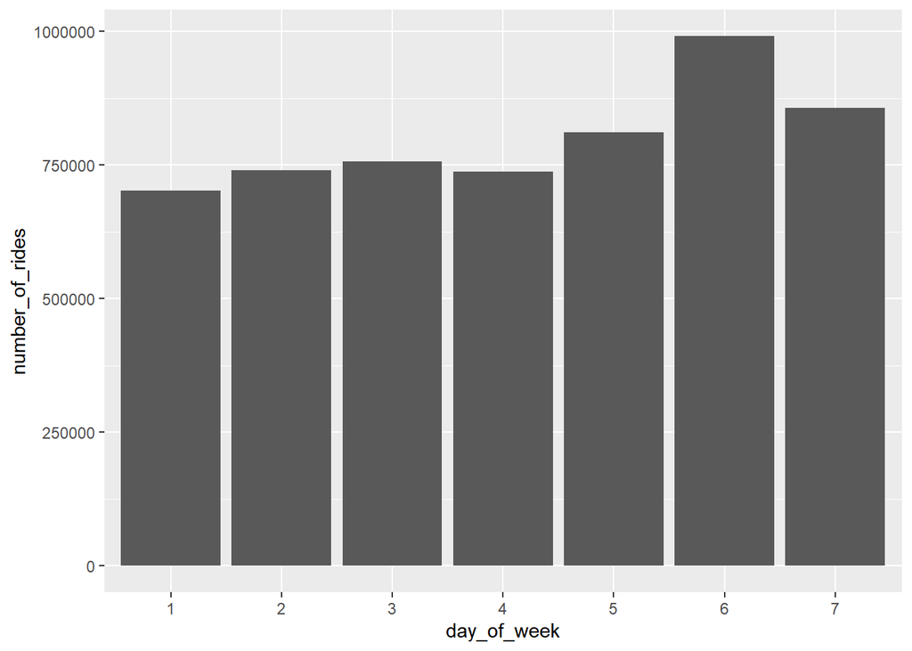

```r
all_trips_v1 %>%
  group_by(day_of_week) %>%
  summarise(number_of_rides = n()) %>%
  ggplot(mapping = aes(x = day_of_week, y = number_of_rides)) + geom_col()
```

The plot shows that most rides were made on Saturday, Sunday followed by Friday. So most bikes are rented on the weekends.

Next, a plot of the ride_length or average_duration in minutes for every day of the week for members and casual riders is shown.

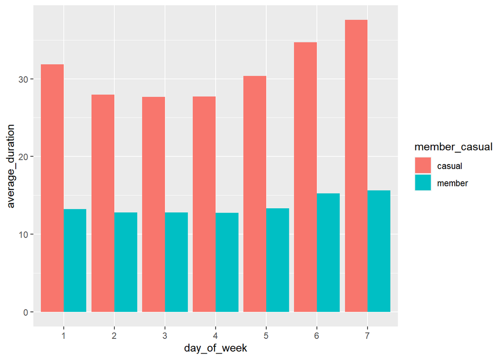

```r
all_trips_v1 %>%
  group_by(member_casual, day_of_week) %>%
  summarise(number_of_rides = n()
            ,average_duration = mean(ride_length_m)) %>%
  arrange(member_casual, day_of_week)  %>%
  ggplot(aes(x = day_of_week, y = average_duration, fill = member_casual)) +
  geom_col(position = "dodge")
```

The plot demonstrates that casual riders rent bikes for longer durations, especially on Sunday, Saturday, Friday (weekend) and on Monday. Members show a steady riding/using behavior, plus they also tend to ride a little longer on the weekend.

Here, number of rides per day for every rider type is plotted.

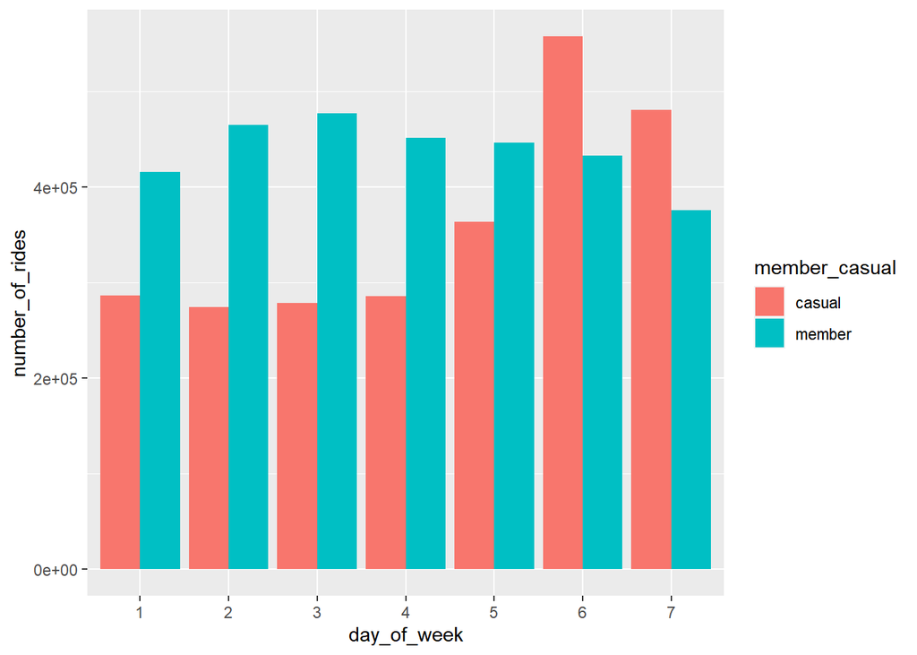

```r
all_trips_v1 %>%
  group_by(member_casual, day_of_week) %>%
  summarise(number_of_rides = n()
            ,average_duration = mean(ride_length_m)) %>%
  arrange(member_casual, day_of_week)  %>%
  ggplot(aes(x = day_of_week, y = number_of_rides, fill = member_casual)) +
  geom_col(position = "dodge")
```

Surprisingly, and in contrast to the former plot, members begin more rides and thus have higher number of rides on every day of the week except for Saturday and Sunday.

Number of rides per week day

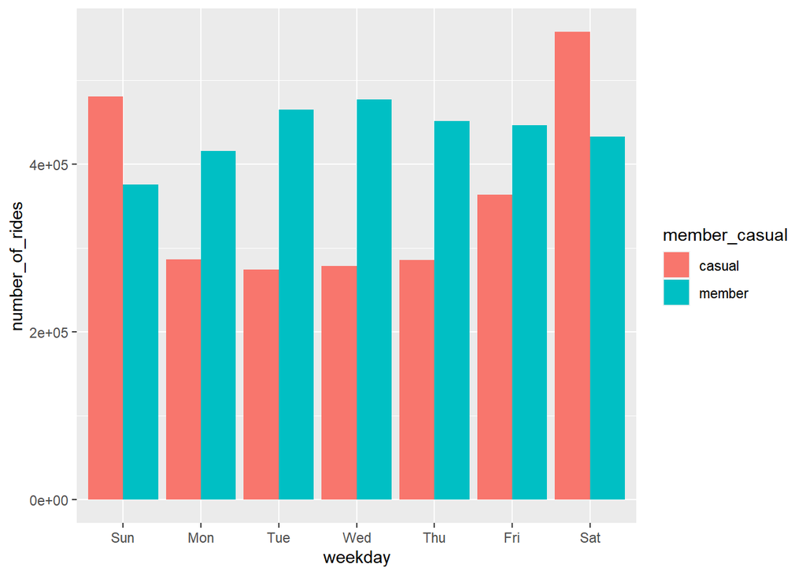

```r
all_trips %>%
  mutate(weekday = wday(started_at, label = TRUE)) %>%  #weekday field
  group_by(member_casual, weekday) %>%                  #group by usertype and weekday
  summarise(number_of_rides = n()
            ,average_duration = mean(ride_length)) %>%  #average duration
  arrange(member_casual, weekday)  %>%                  #Sort
  #visualization
  ggplot(aes(x = weekday, y = number_of_rides, fill = member_casual)) +
  geom_col(position = "dodge")
```

#### Second analysis step: average ride length depending on rider type and number of each rider type

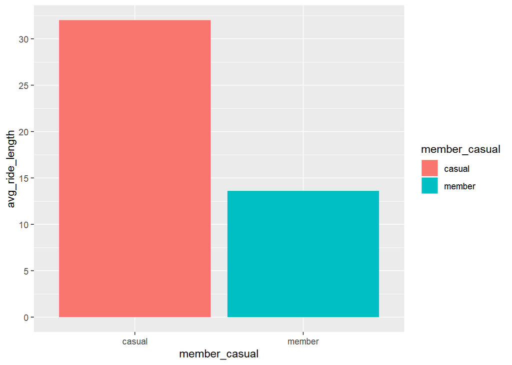

```r
all_trips_v1 %>%
  group_by(member_casual) %>%
  summarise(max(ride_length_m), min(ride_length_m),avg_ride_length = mean(ride_length_m)) %>%
  ggplot(aes(x = member_casual, y = avg_ride_length,fill=member_casual)) +
  geom_col()+ scale_y_continuous(breaks = seq(0, 40, by = 5))
```

So, the result shows that casual riders tend to rent bikes for longer mean durations than members , in accordance with plot 2. Members probably use bikes to commute, whereas casual riders maybe, among other things, exercising, visiting the city or attending special events.

Here, the overall rider count based on rider type is plotted

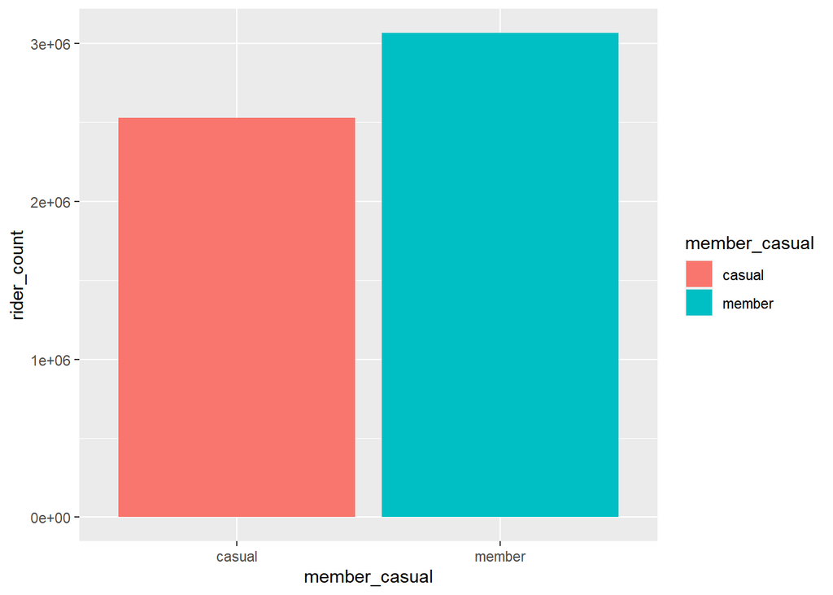

```r
all_trips_v1 %>%
  group_by(member_casual) %>%
  summarise(rider_count = n()) %>%
  ggplot(aes(x = member_casual, y = rider_count,fill=member_casual )) +
  geom_col()
```

The plot indicates that more than half of all riders are member riders.

Average Duration vs Weekday

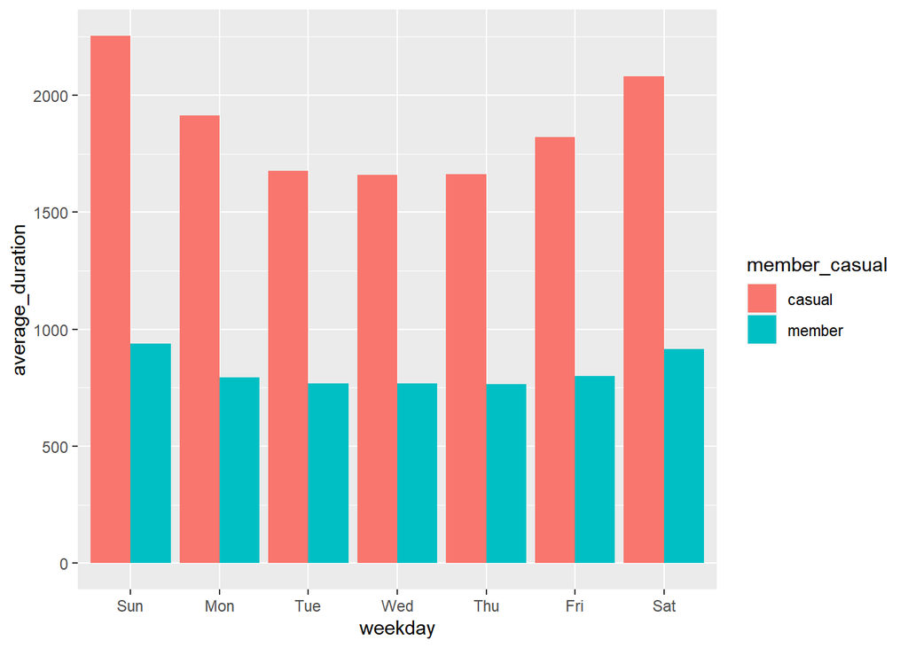

```r
all_trips %>%
  mutate(weekday = wday(started_at, label = TRUE)) %>%
  group_by(member_casual, weekday) %>%
  summarise(number_of_rides = n()
            ,average_duration = mean(ride_length)) %>%
  arrange(member_casual, weekday)  %>%
  ggplot(aes(x = weekday, y = average_duration, fill = member_casual)) +
  geom_col(position = "dodge")
```

Distributed within the weekday

```r
all_trips %>%
  group_by(day_of_week) %>%
  summarise(count = length(ride_id),
            '%' = (length(ride_id) / nrow(all_trips)) * 100,
            'member' = (sum(member_casual == "member") / length(ride_id)) * 100,
            'casual' = (sum(member_casual == "casual") / length(ride_id)) * 100,
            'Member x Casual Perc Diferrent' = member - casual)
```

```
## # A tibble: 7 × 6
##   day_of_week  count   `%` member casual `Member x Casual Perc Diferrent`
##   <chr>        <int> <dbl>  <dbl>  <dbl>                            <dbl>
## 1 1           702588  12.6   59.2   40.8                             18.5
## 2 2           739905  13.2   62.9   37.1                             25.8
## 3 3           756142  13.5   63.1   36.9                             26.2
## 4 4           737588  13.2   61.2   38.8                             22.4
## 5 5           810508  14.5   55.1   44.9                             10.2
## 6 6           991047  17.7   43.7   56.3                            -12.6
## 7 7           857285  15.3   43.9   56.1                            -12.2
```

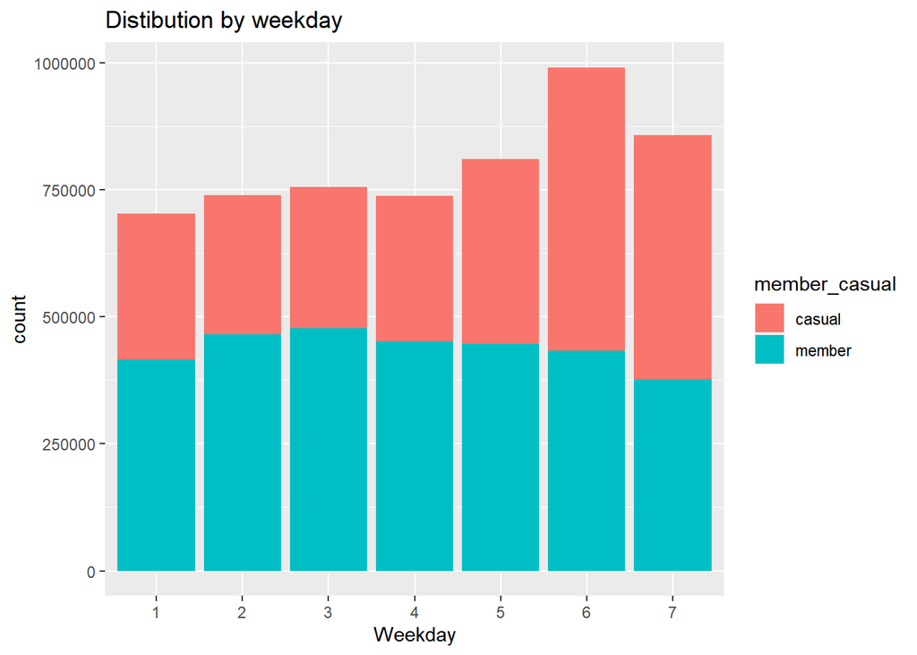

```r
ggplot(all_trips, aes(day_of_week, fill=member_casual)) +
  geom_bar() +
  labs(x="Weekday", title = "Distibution by weekday")
```

Distributed by ride type

```r
all_trips %>%
  group_by(rideable_type) %>%
  summarise(count = length(ride_id),
            '%' = (length(ride_id) / nrow(all_trips)) * 100,
            'member' = (sum(member_casual == "member") / length(ride_id)) * 100,
            'casual' = (sum(member_casual == "casual") / length(ride_id)) * 100,
            'Member x Casual Perc Diferrent' = member - casual)
```

```
## # A tibble: 3 × 6
##   rideable_type   count   `%`    member casual `Member x Casual Perc Diferrent`
##   <chr>           <int> <dbl>     <dbl>  <dbl>                            <dbl>
## 1 classic_bike  3251028 58.1  61.0        39.0                            22.1
## 2 docked_bike    312343  5.58  0.000320  100.                           -100.
## 3 electric_bike 2031692 36.3  53.2        46.8                             6.48
```

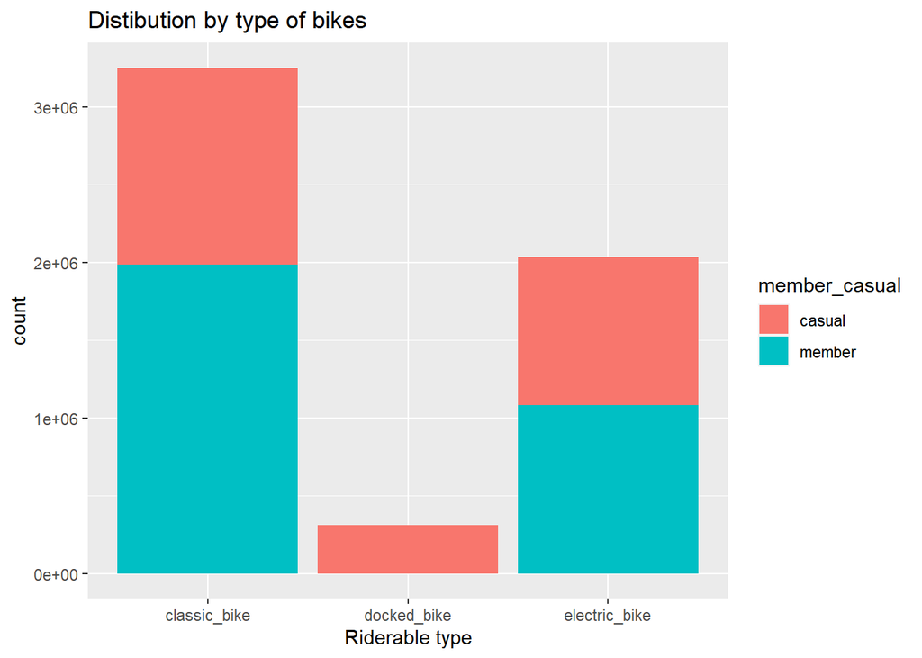

```r
ggplot(all_trips, aes(rideable_type, fill=member_casual)) +
  geom_bar() +
  labs(x="Riderable type", title = "Distibution by type of bikes")
```

#### Third analysis step: Exploring effect of seasonality

Here, the Function “season” of the library “metR” was used to assign season to months:

DJF:winter MAM:Spring JJA:Summer SON:Fall

```r
all_trips_v1$season <- season(all_trips_v1$month)
```

First, let us consider number of rides and ride length by weekday on each season.

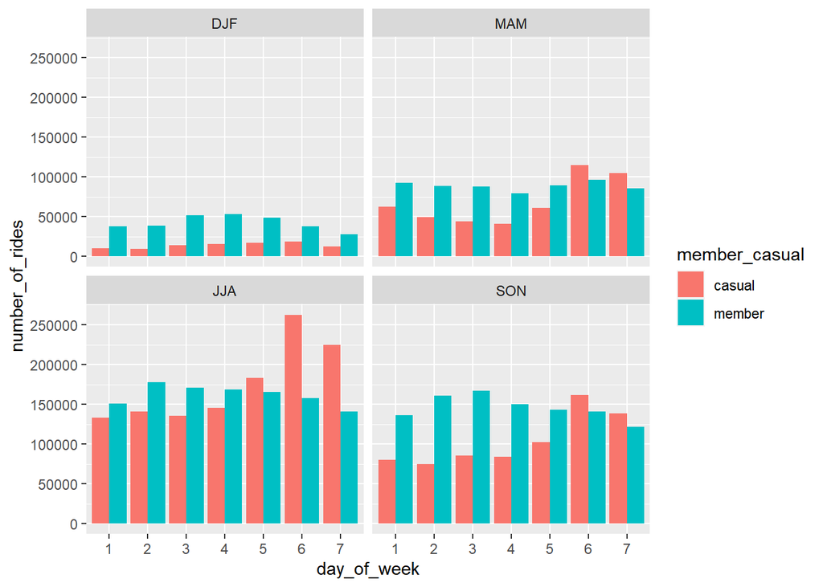

```r
all_trips_v1%>%
  group_by(season, day_of_week, member_casual) %>%
  summarise(number_of_rides = n()
  ,avg_ride_length = mean(ride_length_m)) %>%
ggplot() + geom_col(mapping = aes(x = day_of_week, y = number_of_rides, fill = member_casual), position = "dodge") + facet_wrap(~season) + scale_y_continuous(breaks = seq(0, 400000, by = 50000))
```

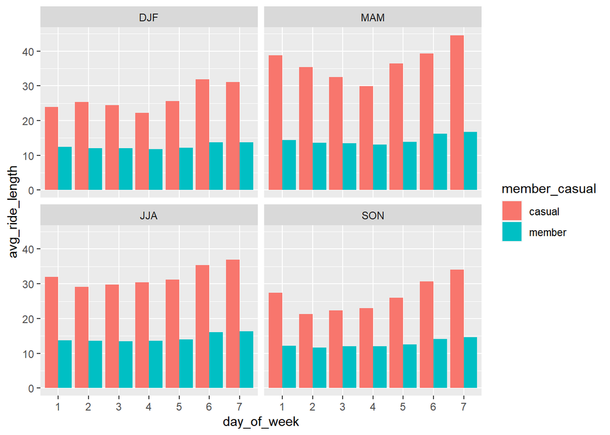

```r
all_trips_v1%>%
  group_by(season, day_of_week, member_casual) %>%
  summarise(number_of_rides = n()
  ,avg_ride_length = mean(ride_length_m)) %>%
ggplot() + geom_col(mapping = aes(x = day_of_week, y = avg_ride_length, fill = member_casual), position = "dodge") + facet_wrap(~season) + scale_y_continuous(breaks = seq(0, 50, by = 10))
```

Lastly, let us generate a line plot for continuous change of number of rides along the whole year for the two rider types.

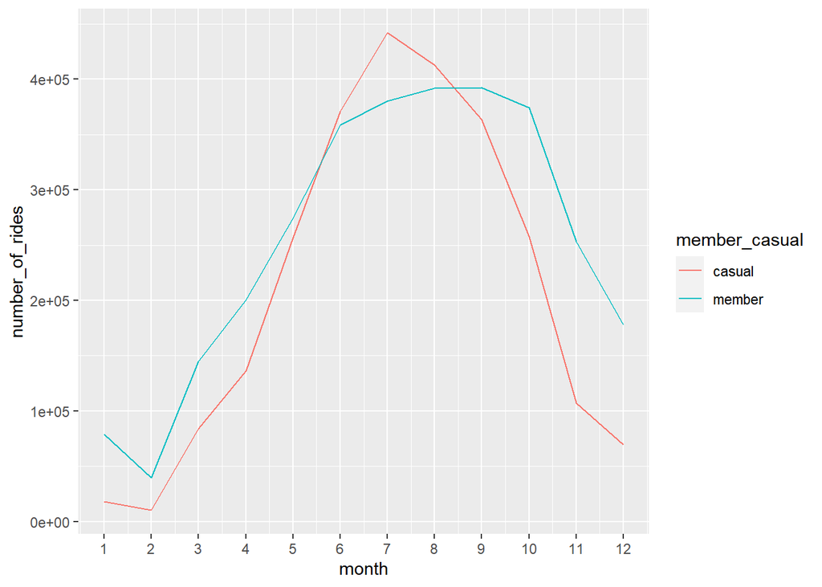

```r
all_trips_v1%>%
  group_by(month, member_casual) %>%
  summarise(number_of_rides = n()
  ,avg_ride_length = mean(ride_length_m)) %>%
ggplot() + geom_line(mapping = aes(x = month, y = number_of_rides, color = member_casual)) + scale_x_continuous(breaks = seq(1, 12, by = 1))
```

The plot indicates, for casual riders/members, ridership peaked around July/August (Summer months being the turning point) and hit the lowest at February before rebounding up swiftly and continuously.

#### Guiding Questions

- **How should you organize your data to perform analysis on it?**

  All data sets should be combined into one set.
- **Has your data been properly formatted?**

  Yes, my data has been properly formatted. All the columns have correct data type.
- **What surprises did you discover in the data?**

#### Exporting the data for future purpose

```r
write.csv(all_trips_v1, file = "data.csv")
```

## Share Phase

#### Recommendations

- Give discounts for longer rides when you have a membership.
- Longer rides can get some type of rewards program when they become members.
- The marketing campaign should be launched between February to August, as the number of trips made by casual riders peaks at this time of the year.
- As casual rider usage reach its highest point on the weekend, the marketing campaign can include weekend-only membership at a sensible price. This could attract casual riders to convert to members.
- The campaign could include ride-length-based tariff plan (maybe only on weekends): Bike more, pay less ! This provides more incentive for the member rides to cycle longer distances.
- Alternatively, longer rides can be rewarded with benefits such as discount vouchers.